# US Severe Weather impacts on Health and Economic Sectors

Sooihk Ro

10/27/2021

## Synopsis

For this report, the US National Oceanic and Atmospheric Administration’s (NOAA) database will be analyzed to determine which types of events are most harmful with respect to population health and have the greatest economic consequences. Analysis determined that tornadoes to be the most harmful weather event on population health and floods to be the most economically harmful type of weather event. NOAA’s database can be downloaded from the course website:

- Dataset: [Storm Data](https://d396qusza40orc.cloudfront.net/repdata%2Fdata%2FStormData.csv.bz2) [47Mb]

## Data Processing

### Loading the dataset

Download the data zip file and unzip it. Read csv file if data object does not exist in environment.

```r
setwd("C:/Users/aduro/Desktop/Coding/Data Science Coursera/Data Science Specialization/5 Reproducible Research/Module 4/")
library(ggplot2)
library(dplyr)
library(lubridate)
library(reshape2)
library(tidyr)
#set directory


stormFile <- "repdata_data_StormData.csv.bz2"
#if zip file does not exist, download from web
if(!file.exists(stormFile)) {
    download_url <- "https://d396qusza40orc.cloudfront.net/repdata%2Fdata%2FStormData.csv.bz2"
    download.file(download_url, destfile = stormFile)
}

if(!exists("stormData")){
    stormData <- read.csv("repdata_data_StormData.csv.bz2")
}
```

### Examing structure of dataset

```r
str(stormData)
```

```
## 'data.frame':    902297 obs. of  37 variables:
##  $ STATE__   : num  1 1 1 1 1 1 1 1 1 1 ...
##  $ BGN_DATE  : chr  "4/18/1950 0:00:00" "4/18/1950 0:00:00" "2/20/1951 0:00:00" "6/8/1951 0:00:00" ...
##  $ BGN_TIME  : chr  "0130" "0145" "1600" "0900" ...
##  $ TIME_ZONE : chr  "CST" "CST" "CST" "CST" ...
##  $ COUNTY    : num  97 3 57 89 43 77 9 123 125 57 ...
##  $ COUNTYNAME: chr  "MOBILE" "BALDWIN" "FAYETTE" "MADISON" ...
##  $ STATE     : chr  "AL" "AL" "AL" "AL" ...
##  $ EVTYPE    : chr  "TORNADO" "TORNADO" "TORNADO" "TORNADO" ...
##  $ BGN_RANGE : num  0 0 0 0 0 0 0 0 0 0 ...
##  $ BGN_AZI   : chr  "" "" "" "" ...
##  $ BGN_LOCATI: chr  "" "" "" "" ...
##  $ END_DATE  : chr  "" "" "" "" ...
##  $ END_TIME  : chr  "" "" "" "" ...
##  $ COUNTY_END: num  0 0 0 0 0 0 0 0 0 0 ...
```

[output cut: 23 more lines]

There are 902,297 observations with 37 variables. We only need a subset from this dataset concerning health and economic impacts.

### Selecting variables of interest

The following variables were selected from the main database for our analysis:

- BGN_DATE: year of event
- EVTYPE: type of events
- FATALITIES: number of approximated deaths
- INJURIES: number of approximated injuries
- PROPDMG: approximated property damage
- PROPDMGEXP: property damage exponent
- CROPDMG: approximated crop damage
- CROPDMGEXP: crop damage exponent

From our subselected data, events before 1996 were excluded because only a small subset of events were listed which limits our analysis. Events where there were no economic of health impacts are also excluded. Variables PROPEXP and CROPEXP represent the magnitude of cost in single digits, thousands(K), millions(M), and billions(B). The former variables were converted from character symbols to represent dollars in numeric values.

```r
report_storm_Data <- select(stormData, BGN_DATE, EVTYPE, FATALITIES, INJURIES, PROPDMG, PROPDMGEXP, CROPDMG, CROPDMGEXP)

#Format BGN_DATE as a date variable
report_storm_Data$BGN_DATE <- as.Date(report_storm_Data$BGN_DATE, "%m/%d/%Y")
#Make a year variable
report_storm_Data$Year <- year(report_storm_Data$BGN_DATE)

#Filter out events before 1996 and select only events where there were damages
report_storm_Data <- filter(report_storm_Data, Year > 1995)
report_storm_Data <- filter(report_storm_Data, FATALITIES > 0 | INJURIES > 0 | PROPDMG > 0 | CROPDMG > 0)

#convert PROPDMGEXP and CROPDMGEXP variables to represent numeric values
report_storm_Data$PROPDMGEXP[!grepl("K|M|B", report_storm_Data$PROPDMGEXP, ignore.case = TRUE)] <- 1
report_storm_Data$PROPDMGEXP[grep("K", report_storm_Data$PROPDMGEXP, ignore.case = TRUE)] <- 1000
report_storm_Data$PROPDMGEXP[grep("M", report_storm_Data$PROPDMGEXP, ignore.case = TRUE)] <- 1000000
report_storm_Data$PROPDMGEXP[grep("B", report_storm_Data$PROPDMGEXP, ignore.case = TRUE)] <- 1000000000

report_storm_Data$CROPDMGEXP[!grepl("K|M|B", report_storm_Data$CROPDMGEXP, ignore.case = TRUE)] <- 1
report_storm_Data$CROPDMGEXP[grep("K", report_storm_Data$CROPDMGEXP, ignore.case = TRUE)] <- 1000
report_storm_Data$CROPDMGEXP[grep("M", report_storm_Data$CROPDMGEXP, ignore.case = TRUE)] <- 1000000
report_storm_Data$CROPDMGEXP[grep("B", report_storm_Data$CROPDMGEXP, ignore.case = TRUE)] <- 1000000000
table(report_storm_Data$PROPDMGEXP)
```

```
##
##      1   1000  1e+06  1e+09
##   8448 185474   7364     32
```

```r
table(report_storm_Data$CROPDMGEXP)
```

```
##
##      1   1000  1e+06  1e+09
## 102767  96787   1762      2
```

```r
#make 2 variables to hold property and crop damage cost
report_storm_Data <- mutate(report_storm_Data, PROPDMGCOST = PROPDMG * as.numeric(PROPDMGEXP), CROPDMGCOST = CROPDMG * as.numeric(CROPDMGEXP))

#fix duplicates based on upper case
report_storm_Data$EVTYPE <- toupper(report_storm_Data$EVTYPE)
```

## Results

### Events most harmful with respect to population health

The top 10 weather events that have the most impact on human health were chosen by estimating the total injuries and fatalities for each event. Plot 1 shows that the most dangerous events on health are tornadoes, excessive heat and floods.

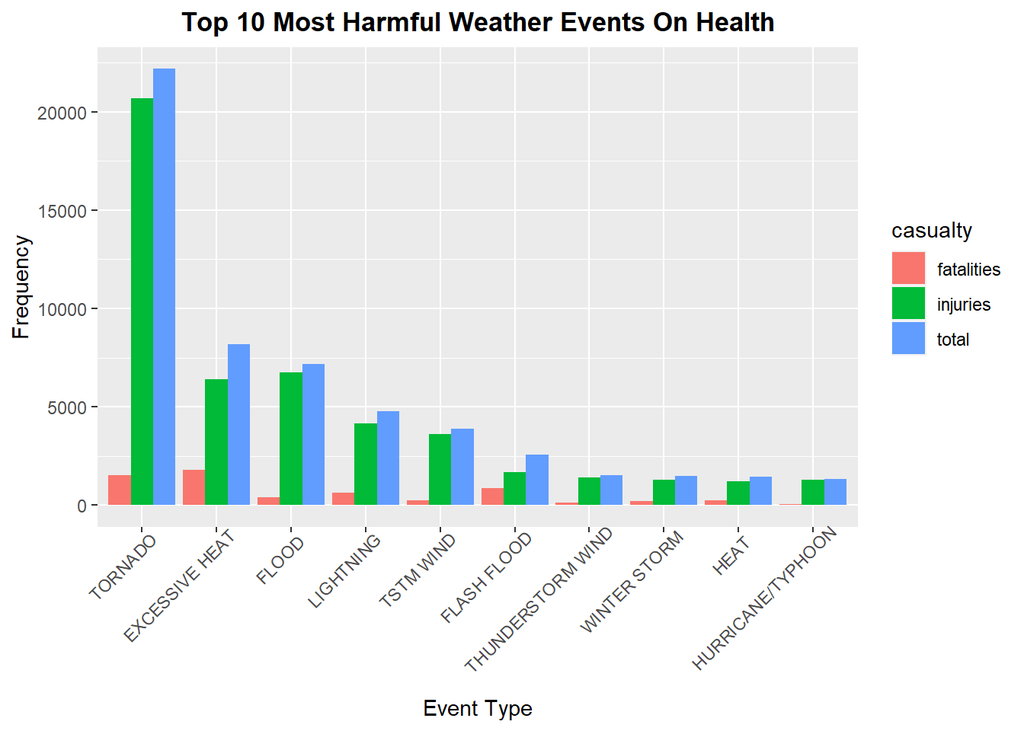

```r
#select top 10 injury and fatality events
health_Impact <- select(report_storm_Data, EVTYPE, INJURIES, FATALITIES) %>% group_by(EVTYPE) %>% summarise(injuries=sum(INJURIES), fatalities=sum(FATALITIES), total = sum(INJURIES) + sum(FATALITIES)) %>% arrange(desc(total)) %>% head(10)

#use pivot longer to transform dataset to make it easier to barplot
long_health_Impact <- pivot_longer(health_Impact, -EVTYPE, names_to="casualty", values_to = "value")

ggplot(long_health_Impact, aes(x=reorder(EVTYPE, -value), y=value)) + geom_bar(stat="identity",aes(fill=casualty), position="dodge") + labs(x="Event Type", y="Frequency", title="Top 10 Most Harmful Weather Events On Health") + theme(plot.title=element_text(face="bold",hjust=0.5 ), axis.text.x = element_text(angle=45, hjust=0.9))
```

### Events having the greatest economic consequences

The top 10 weather events that have the most economic impact were chosen by estimating crop and property damages for each event. Based on the plot 2, floods, hurricanes/typhoones, and storm surges cause the most economic impact on our society.

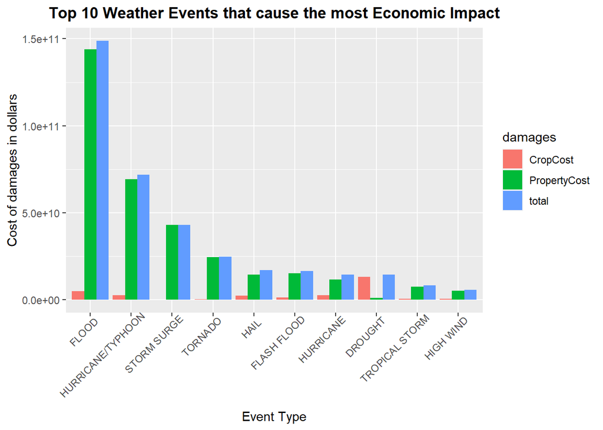

```r
#select top 10 events causing most property and crop damage
economic_Impact <- select(report_storm_Data, EVTYPE, PROPDMGCOST, CROPDMGCOST) %>% group_by(EVTYPE) %>% summarise(PropertyCost=sum(PROPDMGCOST), CropCost=sum(CROPDMGCOST), total=sum(PROPDMGCOST)+sum(CROPDMGCOST)) %>% arrange(desc(total)) %>% head(10)

#transform database with pivot_longer to a more suitable database for bar plotting
long_economic_Impact <- pivot_longer(economic_Impact, -EVTYPE, names_to = "damages", values_to = "value")

ggplot(long_economic_Impact, aes(x=reorder(EVTYPE, -value), y=value)) + geom_bar(stat="identity", aes(fill=damages), position="dodge") + labs(x="Event Type", y="Cost of damages in dollars", title="Top 10 Weather Events that cause the most Economic Impact") + theme(plot.title=element_text(face="bold", hjust=0.5), axis.text.x=element_text(angle=45, hjust=0.9))
```